# practical machine learning final project

2022-12-22

## Overview

Using devices such as Jawbone Up, Nike FuelBand, and Fitbit it is now possible to collect a large amount of data about personal activity relatively inexpensively. These type of devices are part of the quantified self movement - a group of enthusiasts who take measurements about themselves regularly to improve their health, to find patterns in their behavior, or because they are tech geeks. One thing that people regularly do is quantify how much of a particular activity they do, but they rarely quantify how well they do it.

In this project, we will use data from accelerometers on the belt, forearm, arm, and dumbell of 6 participants. They were asked to perform barbell lifts correctly and incorrectly in 5 different ways.

The data consists of a Training data and a Test data (to be used to validate the selected model).

The goal of your project is to predict the manner in which they did the exercise. This is the “classe” variable in the training set. You may use any of the other variables to predict with.

Importing the necessary libraries:

```r
library(caret)
```

```r
library(rpart)
library(rpart.plot)
library(randomForest)
library(corrplot)
library(gbm)
library(RColorBrewer)
library(rattle)
```

## Getting the data

We import the data from the csv provided in the links: There are 2 datasets: 1.-pml-Training 2.-pml-testing

```r
train_in <- read.csv('./pml-training.csv', header=T)
RealCases <- read.csv('./pml-testing.csv', header=T)
dim(train_in)
```

```
## [1] 19622   160
```

```r
dim(RealCases)
```

```
## [1]  20 160
```

## Cleaning the input data

```r
trainData<- train_in[, colSums(is.na(train_in)) == 0]
RData <- RealCases[, colSums(is.na(RealCases)) == 0]
```

Exploring the dataset, we note that there are columns with timestamps and names associated with the user. This data is’nt needed and it generates noise, we remove it from our datasets.

```r
trainData <- trainData[, -c(1:7)]
RData <- RData[, -c(1:7)]
```

## Preparing the datasets for prediction

```r
set.seed(9503)
inTrain <- createDataPartition(trainData$classe, p = 0.7, list = FALSE)
trainData <- trainData[inTrain, ]
testData <- trainData[-inTrain, ]
```

## Remove near-zero-variance variables.

```r
NearZeroV <- nearZeroVar(trainData)
trainData <- trainData[, -NearZeroV]
testData  <- testData[, -NearZeroV]

dim(trainData)
```

```
## [1] 13737    53
```

```r
dim(testData)
```

```
## [1] 4142   53
```

```r
dim(RData)
```

```
## [1] 20 53
```

##Exploring the correlation between variables: The use a correlation plot ordered by the line that best accounts for the shape of the point swarm. It represents the maximum variance direction in the data.

```r
#cor_mat <- cor(trainData[, -49])
#corrplot(cor_mat, order = "FPC", method = "circle", type = "lower",  tl.cex = 0.5)
```

#Model building

1.Classification trees/ regression trees ( the data seems continuous) 2.Random forests 3.Generalized Boosted Model 4.Support Vector Machines 5.Prediction with classification trees

#1(a).- Classification Trees

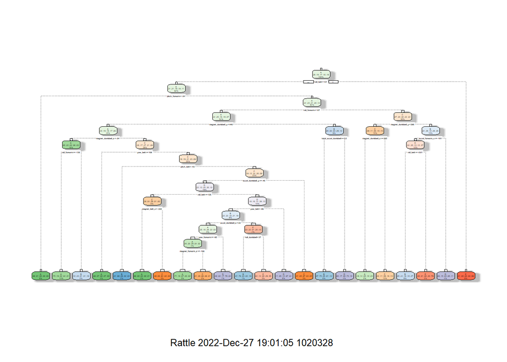

```r
set.seed(9503)

decisionTreeMod1 <- rpart(classe ~ ., data=trainData, method="class")
fancyRpartPlot(decisionTreeMod1)
```

```r
predictTreeMod1 <- predict(decisionTreeMod1, testData, type = "class")

cmtree1 <- confusionMatrix(predictTreeMod1, as.factor(testData$classe))

cmtree1
```

```
## Confusion Matrix and Statistics
##
##           Reference
## Prediction    A    B    C    D    E
##          A 1039  143   27   49   35
##          B   49  483   59   60  160
##          C   26   91  607  100   90
##          D   40   63   41  423   50
##          E    9   16    0   38  444
##
## Overall Statistics
##
##                Accuracy : 0.7233
##                  95% CI : (0.7094, 0.7369)
##     No Information Rate : 0.2808
##     P-Value [Acc > NIR] : < 2.2e-16
##
##                   Kappa : 0.6491
##
##  Mcnemar's Test P-Value : < 2.2e-16
##
## Statistics by Class:
##
##                      Class: A Class: B Class: C Class: D Class: E
## Sensitivity            0.8934   0.6068   0.8270   0.6313   0.5700
## Specificity            0.9147   0.9020   0.9099   0.9441   0.9813
## Pos Pred Value         0.8036   0.5956   0.6641   0.6856   0.8757
## Neg Pred Value         0.9565   0.9060   0.9607   0.9299   0.9078
## Prevalence             0.2808   0.1922   0.1772   0.1618   0.1881
## Detection Rate         0.2508   0.1166   0.1465   0.1021   0.1072
## Detection Prevalence   0.3122   0.1958   0.2207   0.1490   0.1224
## Balanced Accuracy      0.9041   0.7544   0.8684   0.7877   0.7756
```

plot matrix results

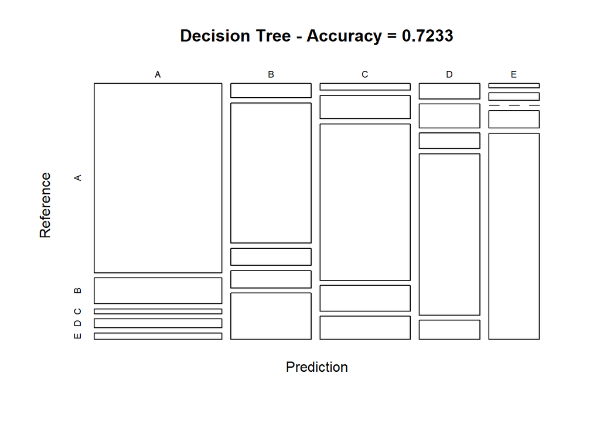

```r
plot(cmtree1$table, col = cmtree1$byClass, main = paste("Decision Tree - Accuracy =", round(cmtree1$overall['Accuracy'], 4)))
```

We see that the accuracy rate of the model is low:

##1(b).- Regression trees ( the data seems continuous)

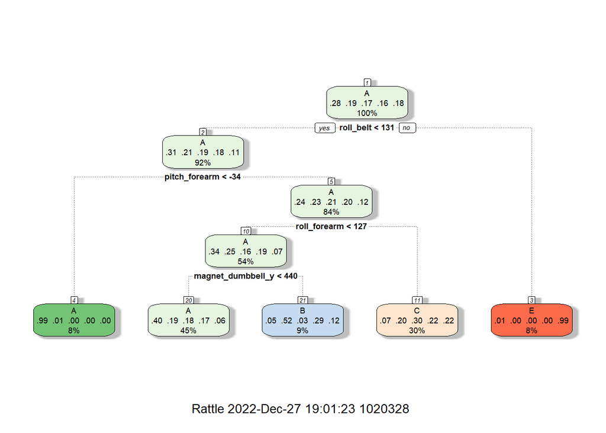

```r
set.seed(9503)
decisionTreeMod2 <- train(classe~., data=trainData, method="rpart")
fancyRpartPlot(decisionTreeMod2$finalModel)
```

```r
predictTreeMod2 <- predict(decisionTreeMod2, testData)

cmtree2 <- confusionMatrix(predictTreeMod2, as.factor(testData$classe))

cmtree2
```

```
## Confusion Matrix and Statistics
##
##           Reference
## Prediction    A    B    C    D    E
##          A 1055  348  342  309  116
##          B   16  198   15  112   48
##          C   89  250  377  249  284
##          D    0    0    0    0    0
##          E    3    0    0    0  331
##
## Overall Statistics
##
##                Accuracy : 0.4734
##                  95% CI : (0.4581, 0.4888)
##     No Information Rate : 0.2808
##     P-Value [Acc > NIR] : < 2.2e-16
##
##                   Kappa : 0.3128
##
##  Mcnemar's Test P-Value : NA
##
## Statistics by Class:
##
##                      Class: A Class: B Class: C Class: D Class: E
## Sensitivity            0.9071  0.24874  0.51362   0.0000  0.42490
## Specificity            0.6257  0.94292  0.74413   1.0000  0.99911
## Pos Pred Value         0.4862  0.50900  0.30184      NaN  0.99102
## Neg Pred Value         0.9452  0.84066  0.87660   0.8382  0.88235
## Prevalence             0.2808  0.19218  0.17721   0.1618  0.18807
## Detection Rate         0.2547  0.04780  0.09102   0.0000  0.07991
## Detection Prevalence   0.5239  0.09392  0.30155   0.0000  0.08064
## Balanced Accuracy      0.7664  0.59583  0.62888   0.5000  0.71201
```

Plot matrix results

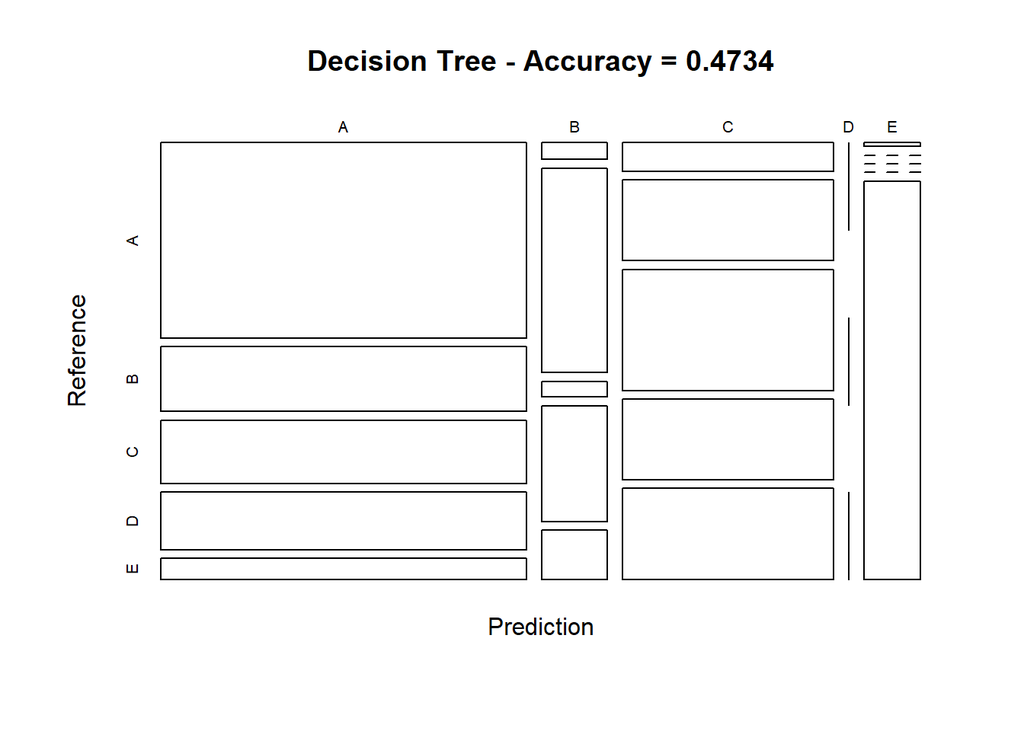

```r
plot(cmtree2$table, col = cmtree2$byClass, main = paste("Decision Tree - Accuracy =", round(cmtree2$overall['Accuracy'],4)))
```

We see that the accuracy rate of the model is low:

#Prediction with Random Forest

1.- Bootstrap Samples 2.- At each split, bootstrap samples 3.- Grow multiple trees and vote

Pros:

1.-Accuracy

Cons: 1.- Speed 2.- Interpretability 3.- Overfitting

We first determine the model

```r
control <- trainControl(method="cv", number=3, verboseIter=FALSE)
mod_RF <- train(classe ~ ., data=trainData, method="rf", trControl=control)
mod_RF$finalModel
```

```
##
## Call:
##  randomForest(x = x, y = y, mtry = param$mtry)
##                Type of random forest: classification
##                      Number of trees: 500
## No. of variables tried at each split: 2
##
##         OOB estimate of  error rate: 0.62%
## Confusion matrix:
##      A    B    C    D    E  class.error
## A 3903    1    1    0    1 0.0007680492
## B   12 2640    6    0    0 0.0067720090
## C    0   16 2376    4    0 0.0083472454
## D    0    0   35 2214    3 0.0168738899
## E    0    0    1    5 2519 0.0023762376
```

```r
predictRF <- predict(mod_RF, newdata=testData)
cm_RF <- confusionMatrix(predictRF, as.factor(testData$classe))
cm_RF
```

```
## Confusion Matrix and Statistics
##
##           Reference
## Prediction    A    B    C    D    E
##          A 1163    0    0    0    0
##          B    0  796    0    0    0
##          C    0    0  734    0    0
##          D    0    0    0  670    0
##          E    0    0    0    0  779
##
## Overall Statistics
##
##                Accuracy : 1
##                  95% CI : (0.9991, 1)
##     No Information Rate : 0.2808
##     P-Value [Acc > NIR] : < 2.2e-16
##
##                   Kappa : 1
##
##  Mcnemar's Test P-Value : NA
##
## Statistics by Class:
##
##                      Class: A Class: B Class: C Class: D Class: E
## Sensitivity            1.0000   1.0000   1.0000   1.0000   1.0000
## Specificity            1.0000   1.0000   1.0000   1.0000   1.0000
## Pos Pred Value         1.0000   1.0000   1.0000   1.0000   1.0000
## Neg Pred Value         1.0000   1.0000   1.0000   1.0000   1.0000
## Prevalence             0.2808   0.1922   0.1772   0.1618   0.1881
## Detection Rate         0.2808   0.1922   0.1772   0.1618   0.1881
## Detection Prevalence   0.2808   0.1922   0.1772   0.1618   0.1881
## Balanced Accuracy      1.0000   1.0000   1.0000   1.0000   1.0000
```

Plot matrix results

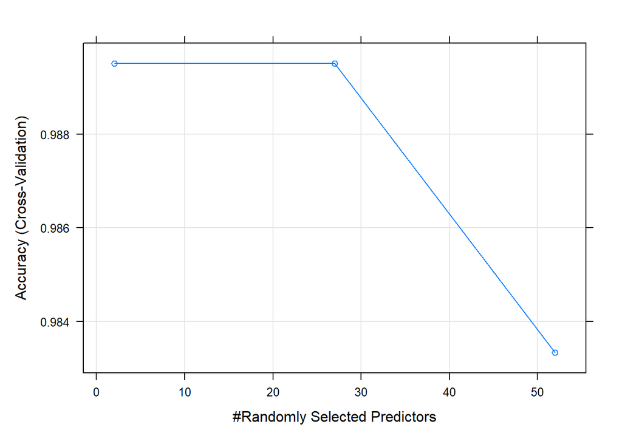

```r
plot(mod_RF)
```

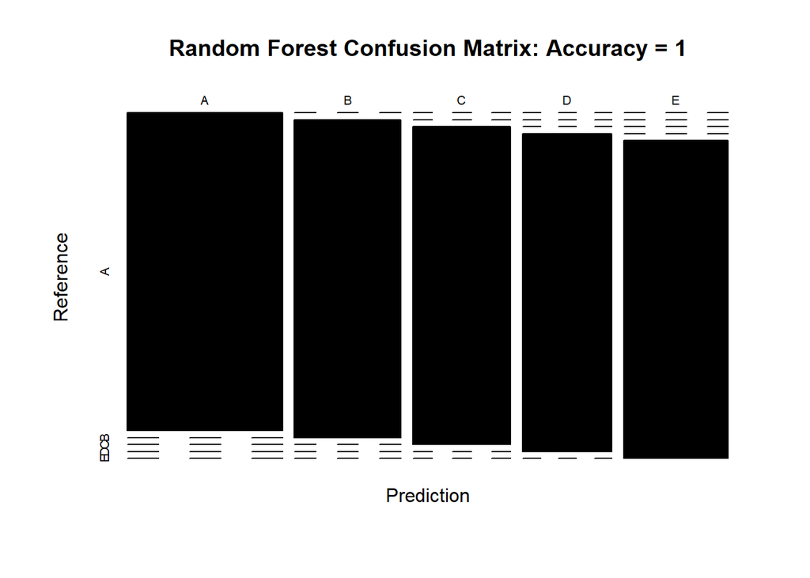

```r
plot(cm_RF$table, col = cm_RF$byClass, main = paste("Random Forest Confusion Matrix: Accuracy =", round(cm_RF$overall['Accuracy'], 4)))
```

##Prediction with Generalized Boosted Regression Models

Boosting can be used with any subset of classifiers

one large sublass is gradient boosting

r has multiple boosting libraries. Differences include the choice of basic classification functions and combinations rules

- gbm boosting with trees
- mboost model based boosting
- ada statistical boosting based on additive logistic regression
- gamBoost for bosting generalized additive models

```r
set.seed(9503)

mod_GBM  <- train(classe ~ ., data=trainData, method = "gbm",  trControl = control, tuneLength = 5, verbose = FALSE)
mod_GBM$finalModel
```

```
## A gradient boosted model with multinomial loss function.
## 250 iterations were performed.
## There were 52 predictors of which 52 had non-zero influence.
```

```r
print(mod_GBM)
```

```
## Stochastic Gradient Boosting
##
## 13737 samples
##    52 predictor
##     5 classes: 'A', 'B', 'C', 'D', 'E'
##
## No pre-processing
## Resampling: Cross-Validated (3 fold)
## Summary of sample sizes: 9158, 9157, 9159
## Resampling results across tuning parameters:
##
##   interaction.depth  n.trees  Accuracy   Kappa
##   1                   50      0.7511831  0.6844992
##   1                  100      0.8207757  0.7731138
##   1                  150      0.8509862  0.8114270
##   1                  200      0.8704233  0.8359986
##   1                  250      0.8854194  0.8549611
##   2                   50      0.8549899  0.8163156
##   2                  100      0.9044185  0.8790406
##   2                  150      0.9289510  0.9100971
##   2                  200      0.9459126  0.9315594
##   2                  250      0.9562498  0.9446482
##   3                   50      0.8937906  0.8655025
##   3                  100      0.9408171  0.9251056
##   3                  150      0.9593799  0.9485975
##   3                  200      0.9706633  0.9628868
##   3                  250      0.9759049  0.9695180
##   4                   50      0.9207977  0.8997384
##   4                  100      0.9566865  0.9452030
##   4                  150      0.9706631  0.9628843
##   4                  200      0.9791803  0.9736622
##   4                  250      0.9828202  0.9782667
##   5                   50      0.9342652  0.9167784
##   5                  100      0.9674600  0.9588311
##   5                  150      0.9782341  0.9724658
##   5                  200      0.9831843  0.9787290
##   5                  250      0.9863145  0.9826894
##
## Tuning parameter 'shrinkage' was held constant at a value of 0.1
##
## Tuning parameter 'n.minobsinnode' was held constant at a value of 10
## Accuracy was used to select the optimal model using the largest value.
## The final values used for the model were n.trees = 250, interaction.depth =
##  5, shrinkage = 0.1 and n.minobsinnode = 10.
```

```r
predictGBM <- predict(mod_GBM, newdata=testData)
cm_GBM <- confusionMatrix(predictGBM, as.factor(testData$classe))
cm_GBM
```

```
## Confusion Matrix and Statistics
##
##           Reference
## Prediction    A    B    C    D    E
##          A 1163    1    0    0    0
##          B    0  795    0    0    0
##          C    0    0  733    1    0
##          D    0    0    1  669    0
##          E    0    0    0    0  779
##
## Overall Statistics
##
##                Accuracy : 0.9993
##                  95% CI : (0.9979, 0.9999)
##     No Information Rate : 0.2808
##     P-Value [Acc > NIR] : < 2.2e-16
##
##                   Kappa : 0.9991
##
##  Mcnemar's Test P-Value : NA
##
## Statistics by Class:
##
##                      Class: A Class: B Class: C Class: D Class: E
## Sensitivity            1.0000   0.9987   0.9986   0.9985   1.0000
## Specificity            0.9997   1.0000   0.9997   0.9997   1.0000
## Pos Pred Value         0.9991   1.0000   0.9986   0.9985   1.0000
## Neg Pred Value         1.0000   0.9997   0.9997   0.9997   1.0000
## Prevalence             0.2808   0.1922   0.1772   0.1618   0.1881
## Detection Rate         0.2808   0.1919   0.1770   0.1615   0.1881
## Detection Prevalence   0.2810   0.1919   0.1772   0.1618   0.1881
## Balanced Accuracy      0.9998   0.9994   0.9992   0.9991   1.0000
```

Plot matrix results

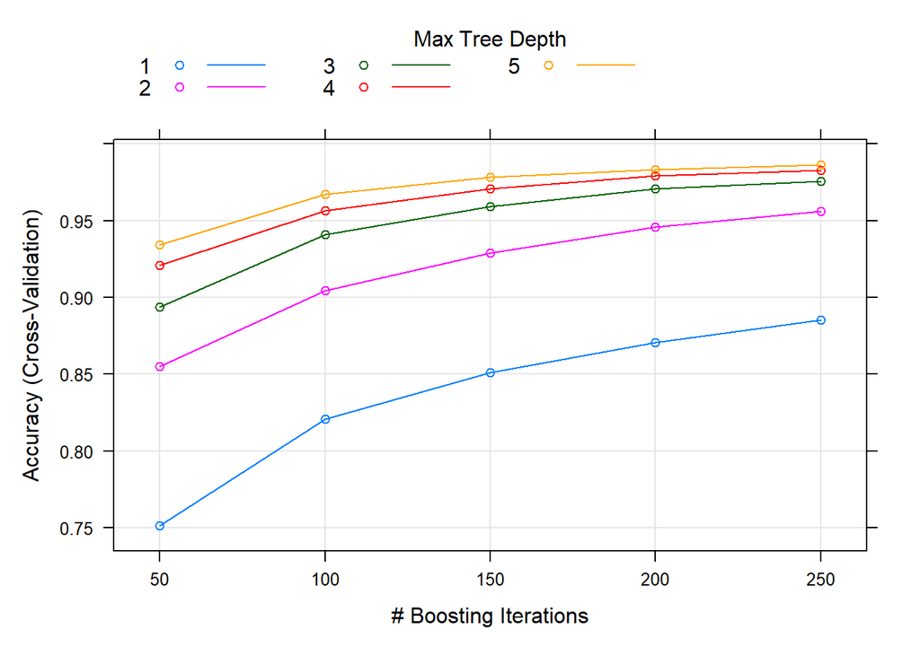

```r
plot(mod_GBM)
```

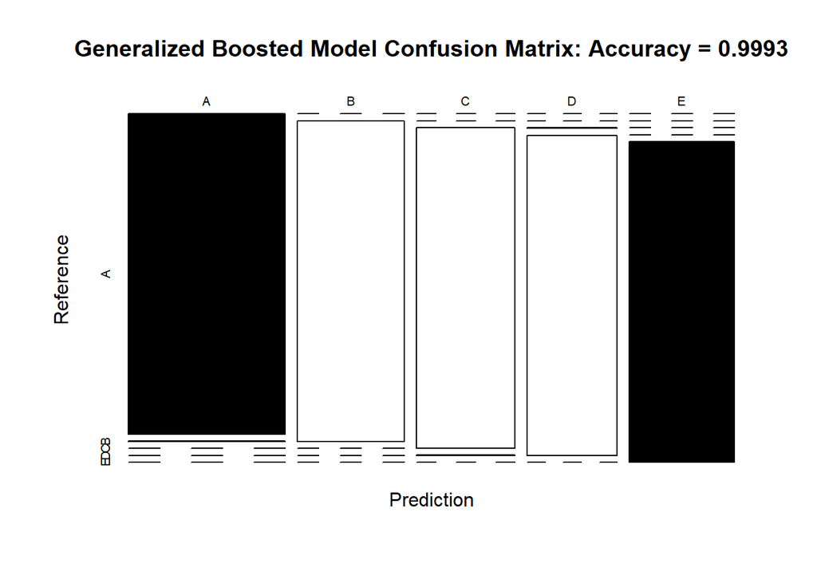

```r
plot(cm_GBM$table, col = cm_GBM$byClass, main = paste("Generalized Boosted Model Confusion Matrix: Accuracy =", round(cm_GBM$overall['Accuracy'], 4)))
```

We see that the accuracy rate of the model is close to 1:

##Support Vector Machine

```r
set.seed(9503)


mod_svm <- train(classe~., data=trainData, method="svmLinear", trControl = control, tuneLength = 5, verbose = F)
mod_svm$finalModel
```

```
## Support Vector Machine object of class "ksvm"
##
## SV type: C-svc  (classification)
##  parameter : cost C = 1
##
## Linear (vanilla) kernel function.
##
## Number of Support Vectors : 7305
##
## Objective Function Value : -1443.409 -1282.105 -1093.301 -635.2144 -1345.219 -916.5797 -1708.86 -1249.691 -1019.801 -1224.892
## Training error : 0.211982
```

```r
print(mod_svm)
```

```
## Support Vector Machines with Linear Kernel
##
## 13737 samples
##    52 predictor
##     5 classes: 'A', 'B', 'C', 'D', 'E'
##
## No pre-processing
## Resampling: Cross-Validated (3 fold)
## Summary of sample sizes: 9158, 9157, 9159
## Resampling results:
##
##   Accuracy   Kappa
##   0.7745497  0.7133592
##
## Tuning parameter 'C' was held constant at a value of 1
```

```r
pred_svm <- predict(mod_svm, testData)

cm_svm <- confusionMatrix(pred_svm, factor(testData$classe))

cm_svm
```

```
## Confusion Matrix and Statistics
##
##           Reference
## Prediction    A    B    C    D    E
##          A 1055  119   61   50   45
##          B   22  550   65   23   95
##          C   43   51  575   83   47
##          D   37   16   20  484   34
##          E    6   60   13   30  558
##
## Overall Statistics
##
##                Accuracy : 0.7779
##                  95% CI : (0.7649, 0.7905)
##     No Information Rate : 0.2808
##     P-Value [Acc > NIR] : < 2.2e-16
##
##                   Kappa : 0.7179
##
##  Mcnemar's Test P-Value : < 2.2e-16
##
## Statistics by Class:
##
##                      Class: A Class: B Class: C Class: D Class: E
## Sensitivity            0.9071   0.6910   0.7834   0.7224   0.7163
## Specificity            0.9077   0.9387   0.9343   0.9692   0.9676
## Pos Pred Value         0.7932   0.7285   0.7196   0.8190   0.8366
## Neg Pred Value         0.9616   0.9274   0.9524   0.9476   0.9364
## Prevalence             0.2808   0.1922   0.1772   0.1618   0.1881
## Detection Rate         0.2547   0.1328   0.1388   0.1169   0.1347
## Detection Prevalence   0.3211   0.1823   0.1929   0.1427   0.1610
## Balanced Accuracy      0.9074   0.8148   0.8588   0.8458   0.8419
```

We see that the accuracy rate of the model is low:

[figure not shown]

```r
plot(cm_svm$table, col = cm_svm$byClass, main = paste("Generalized Boosted Model Confusion Matrix: Accuracy =", round(cm_svm$overall['Accuracy'], 4)))
```

##Prediction of the real data using the best models:

Prediction using Random Forest:

```r
Results1 <- predict(mod_RF, newdata=RData)


Results1
```

```
##  [1] B A B A A E D B A A B C B A E E A B B B
## Levels: A B C D E
```

Prediction using Generalized Boosted Model:

```r
Results2 <- predict(mod_GBM, newdata=RData)


Results2
```

```
##  [1] B A B A A E D B A A B C B A E E A B B B
## Levels: A B C D E
```